# House Price Prediction (Kaggle)

Gabriel Sanchez

# Introduction

In this notebook a model is proposed for predicting the sale price of houses based on the Ames Housing dataset from the “House Prices: Advanced Regression Techniques” Kaggle competition. The data provided includes 2919 houses out of which 1460 are used for training and 1459 for testing. The data requires to be cleaned and machine learning models such as random fores and gradient boosting are explored to make the predictions.

# Import libraries

First we load the necessary libraries that we will be using for analyzing, modelling and plotting.

```r
library(ggplot2)
library(caret)
library(scales)
library(plyr)
library(corrplot)
```

We can now import the data into the train and test variables.

```r
train <- read.csv('train.csv', stringsAsFactors = FALSE)
test <- read.csv('test.csv', stringsAsFactors = FALSE)
```

We will assign the Id column to the test_labels variable since we will use it at the end when we integrate the CSV that will be uploaded to Kaggle. We assign NA to SalePrice in the test set since there are no values for it. We will also join the train and test data and assign it to the all variable.

```r
test_labels <- test$Id
test$SalePrice <- NA
all <- rbind(train, test)
```

# Cleaning

A lot of data is missing from the dataset so first thing we need to do is explore which variable are the ones that are missing more data. We can clearly see that PoolQC is the variable which is missing more data than other which intuitively we can infere that a lot of houses don’t really have a pool so they are assigned NA.

```r
na_col <- which(colSums(is.na(all)) > 0)
sort(colSums(sapply(all[na_col], is.na)), decreasing = TRUE)
```

```
##       PoolQC  MiscFeature        Alley        Fence    SalePrice
##         2909         2814         2721         2348         1459
##  FireplaceQu  LotFrontage  GarageYrBlt GarageFinish   GarageQual
##         1420          486          159          159          159
##   GarageCond   GarageType     BsmtCond BsmtExposure     BsmtQual
##          159          157           82           82           81
## BsmtFinType2 BsmtFinType1   MasVnrType   MasVnrArea     MSZoning
##           80           79           24           23            4
##    Utilities BsmtFullBath BsmtHalfBath   Functional  Exterior1st
##            2            2            2            2            1
##  Exterior2nd   BsmtFinSF1   BsmtFinSF2    BsmtUnfSF  TotalBsmtSF
##            1            1            1            1            1
##   Electrical  KitchenQual   GarageCars   GarageArea     SaleType
##            1            1            1            1            1
```

We will create a function to clean the data.

```r
clean <- function(df){

  quality <- c("None", "Fa", "TA", "Gd", "Ex")
  quality2 <- c("None","Po","Fa", "TA", "Gd", "Ex")
  finish <- c("None"=0, "Unf"=1, "RFn"=2, "Fin"=3)
  exp <- c("None","No", "Mn", "Av", "Gd")
  fin <- c("None","Unf","LwQ","Rec","BLQ","ALQ","GLQ")

  ## Pool
  df[["PoolQC"]][is.na(df[["PoolQC"]])] <- "None"
  #poolqc<-revalue(df[["PoolQC"]], levels=quality)
  poolqc<-factor(df[["PoolQC"]], levels=quality)
  df[["PoolQC"]] <- as.numeric(poolqc)

  ## MiscFeature
  df[["MiscFeature"]][is.na(df[["MiscFeature"]])] <- "None"
  df[["MiscFeature"]] <- as.factor(df[["MiscFeature"]])

  ## Alley
  df[["Alley"]][is.na(df[["Alley"]])] <- "None"
  df[["Alley"]] <- as.factor(df[["Alley"]])

  ## Fence
  df[["Fence"]][is.na(df[["Fence"]])] <- "None"
  df[["Fence"]] <- as.factor(df[["Fence"]])

  ## Fireplace
  df[["FireplaceQu"]][is.na(df[["FireplaceQu"]])] <- "None"
  #fp<-revalue(df[["FireplaceQu"]], levels=quality)
  fp<-factor(df[["FireplaceQu"]], levels=quality2)
  df[["FireplaceQu"]] <- as.numeric(fp)

  ## Lot
  df[["LotFrontage"]][is.na(df[["LotFrontage"]])] <- 69 # media

  ## Garage
  df[["GarageYrBlt"]][is.na(df[["GarageYrBlt"]])] <- 0
  df[["GarageYrBlt"]] <- factor(df[["GarageYrBlt"]])

  df[["GarageFinish"]][is.na(df[["GarageFinish"]])] <- "None"
  #gf <- revalue(df[["GarageFinish"]], finish)
  gf <- factor(df[["GarageFinish"]], finish)
  df[["GarageFinish"]]<-as.integer(gf)

  df[["GarageQual"]][is.na(df[["GarageQual"]])] <- "None"
  df[["GarageQual"]] <- as.numeric(factor(df[["GarageQual"]], levels=quality))

  df[["GarageCond"]][is.na(df[["GarageCond"]])] <- "None"
  df[["GarageCond"]] <- as.numeric(factor(df[["GarageCond"]], levels=quality))

  df[["GarageType"]][is.na(df[["GarageType"]])] <- "None"

  df[["GarageCars"]][is.na(df[["GarageCars"]])] <- 0
  df[["GarageArea"]][is.na(df[["GarageArea"]])] <- 0

  ## Basement
  df[["BsmtCond"]][is.na(df[["BsmtCond"]])] <- "None"
  df[["BsmtCond"]] <- as.numeric(factor(df[["BsmtCond"]], levels=quality))

  df[["BsmtExposure"]][is.na(df[["BsmtExposure"]])] <- "None"
  df[["BsmtExposure"]] <- as.numeric(factor(df[["BsmtExposure"]], levels=exp))

  df[["BsmtQual"]][is.na(df[["BsmtQual"]])] <- "None"
  df[["BsmtQual"]] <- as.numeric(factor(df[["BsmtQual"]], levels=quality))

  df[["BsmtFinType1"]][is.na(df[["BsmtFinType1"]])] <- "None"
  df[["BsmtFinType1"]] <- as.numeric(factor(df[["BsmtFinType1"]], levels=fin))

  df[["BsmtFinType2"]][is.na(df[["BsmtFinType2"]])] <- "None"
  df[["BsmtFinType2"]] <- as.numeric(factor(df[["BsmtFinType2"]], levels=fin))

  df[["BsmtFullBath"]][is.na(df[["BsmtFullBath"]])] <- 0
  df[["BsmtHalfBath"]][is.na(df[["BsmtHalfBath"]])] <- 0
  df[["BsmtFinSF1"]][is.na(df[["BsmtFinSF1"]])] <- 0
  df[["BsmtFinSF2"]][is.na(df[["BsmtFinSF2"]])] <- 0
  df[["BsmtUnfSF"]][is.na(df[["BsmtUnfSF"]])] <- 0
  df[["TotalBsmtSF"]][is.na(df[["TotalBsmtSF"]])] <- 0

  ## Masory
  df[["MasVnrType"]][is.na(df[["MasVnrType"]])] <- "None"
  df[["MasVnrArea"]][is.na(df[["MasVnrArea"]])] <- 0

  ## MSZoning
  df[["MSZoning"]][is.na(df[["MSZoning"]])] <- "RL"

  ## Utilities
  df[["Utilities"]][is.na(df[["Utilities"]])] <- "AllPub"

  ## Functional
  df[["Functional"]][is.na(df[["Functional"]])] <- "Typ"

  ## Exteriors
  df[["Exterior1st"]][is.na(df[["Exterior1st"]])] <- "Other"
  df[["Exterior2nd"]][is.na(df[["Exterior2nd"]])] <- "Other"

  df[["ExterQual"]] <- as.numeric(factor(df[["ExterQual"]], levels=quality))
  df[["ExterCond"]] <- as.numeric(factor(df[["ExterCond"]], levels=quality2))

  ## Electrical
  df[["Electrical"]][is.na(df[["Electrical"]])] <- "SBrkr"

  ## Kitchen Quality
  df[["KitchenQual"]][is.na(df[["KitchenQual"]])] <- "TA"
  df[["KitchenQual"]] <- as.numeric(factor(df[["KitchenQual"]], levels=quality))

  ## Sale Type
  df[["SaleType"]][is.na(df[["SaleType"]])] <- "WD"

  df[["Neighborhood"]]<- as.factor(df[["Neighborhood"]])

  return(df)
}
```

# Feature Engineering

We will create new variables to add to our dataset. This will help us to get better results.

```r
fe <- function(df){

  df[["TotalSF"]] <- df[["TotalBsmtSF"]] + df[["X1stFlrSF"]] + df[["X2ndFlrSF"]]
  df[["OverallGrade"]] <- df[["OverallQual"]] * df[["OverallCond"]]
  df[["ExterGrade"]] <- df[["ExterQual"]] * df[["ExterCond"]]
  df[["FireplaceScore"]] <- df[["Fireplaces"]] * df[["FireplaceQu"]]
  df[["TotalBath"]] <- df[["BsmtFullBath"]] + (0.5 * df[["BsmtHalfBath"]]) +   df[["FullBath"]] + (0.5 * df[["HalfBath"]])
  df[["TotalSqFeet"]] <- df[["GrLivArea"]] + df[["TotalBsmtSF"]]
  df[["TotalPorchSF"]] <- df[["OpenPorchSF"]] + df[["EnclosedPorch"]] +   df[["X3SsnPorch"]] + df[["ScreenPorch"]]
  df[["PoolScore"]] <- df[["PoolArea"]] * df[["PoolQC"]]
  df[["KitchenScore"]] <- df[["KitchenAbvGr"]] * df[["KitchenQual"]]
  df[["Remod"]] <- ifelse(df[["YearBuilt"]]==df[["YearRemodAdd"]], 0, 1)
  df[["Age"]] <- as.numeric(df[["YrSold"]])-df[["YearRemodAdd"]]

    return(df)
}
```

# Update Data

We call the feature engineering and cleaning functions we just created to update our data.

```r
train <- fe(clean(train))
test <- fe(clean(test))
test$SalePrice <- NA
all <- rbind(train, test)
```

# Histogram

We can now take a look to our data through a histogram.

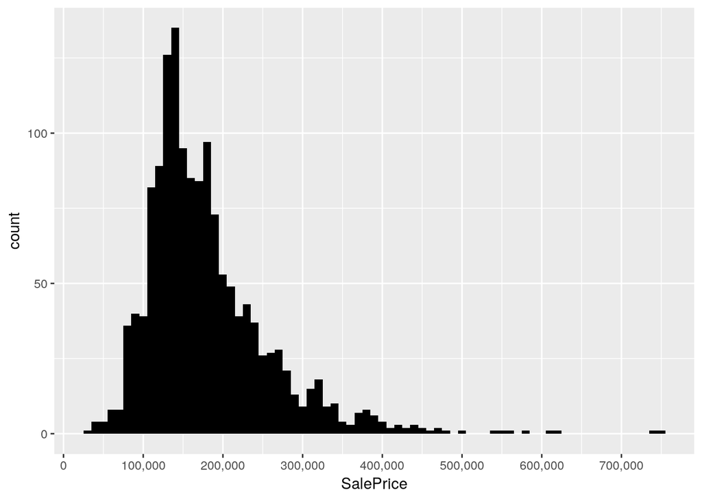

```r
ggplot(data=all[!is.na(all$SalePrice),], aes(x=SalePrice)) +
        geom_histogram(fill="black", binwidth = 10000) +
        scale_x_continuous(breaks= seq(0, 800000, by=100000), labels=comma)
```

We can use a log function to normalize the data. We must revert the values with the exp function before uploading the results to kaggle.

```r
train$SalePrice <- log(train$SalePrice)
```

# Correlation

We want to see which variables have the most correlation with SalePrice with a correlation matrix.

```r
numericVars <- which(sapply(all, is.numeric))
numericVarNames <- names(numericVars)
all_numVar <- all[, numericVars]
cor_numVar <- cor(all_numVar, use="pairwise.complete.obs")
cor_sorted <- as.matrix(sort(cor_numVar[,'SalePrice'], decreasing = TRUE))
cor_high <- names(which(apply(cor_sorted, 1, function(x) abs(x)>0.5)))
cor_high
```

```
##  [1] "SalePrice"      "OverallQual"    "TotalSF"        "TotalSqFeet"
##  [5] "GrLivArea"      "ExterQual"      "KitchenQual"    "GarageCars"
##  [9] "TotalBath"      "GarageArea"     "BsmtQual"       "ExterGrade"
## [13] "TotalBsmtSF"    "X1stFlrSF"      "OverallGrade"   "FullBath"
## [17] "TotRmsAbvGrd"   "YearBuilt"      "FireplaceQu"    "YearRemodAdd"
## [21] "FireplaceScore" "Age"
```

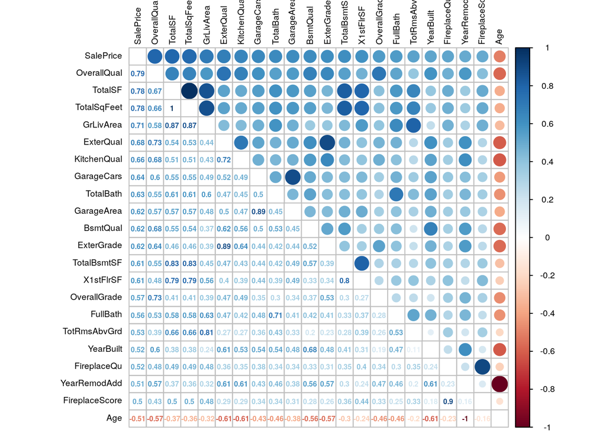

```r
cor_numVar <- cor_numVar[cor_high, cor_high]
corrplot.mixed(cor_numVar, tl.col="black", tl.pos = "lt", tl.cex = .6,cl.cex = .6, number.cex=.5)
```

# Outliers

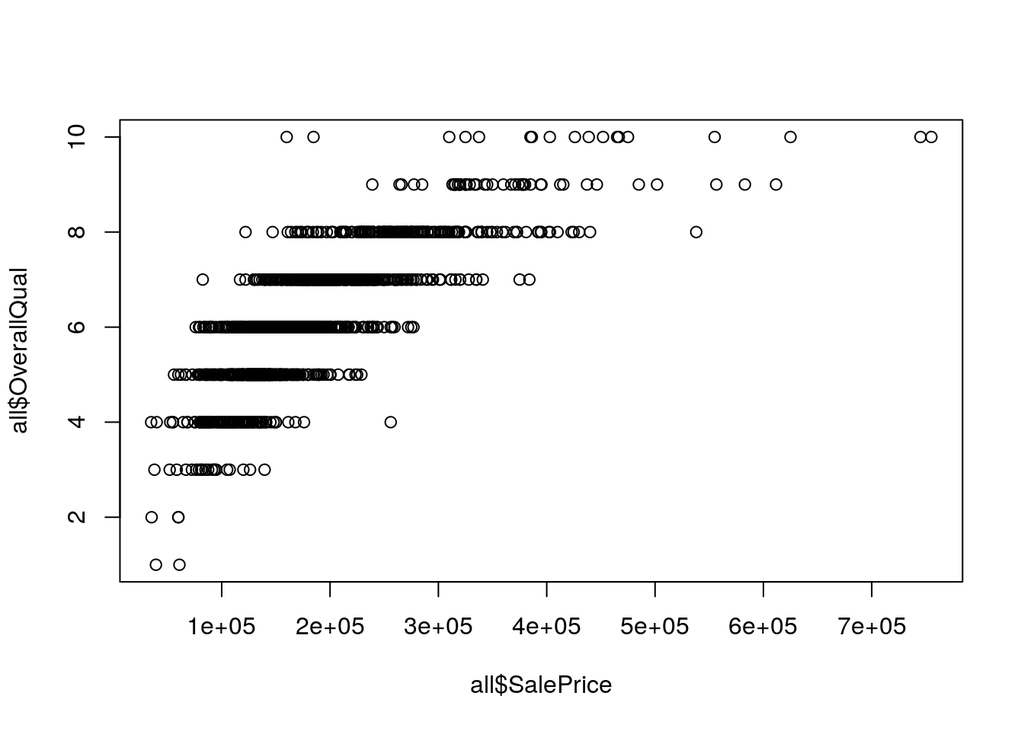

```r
plot(all$SalePrice, all$OverallQual)
```

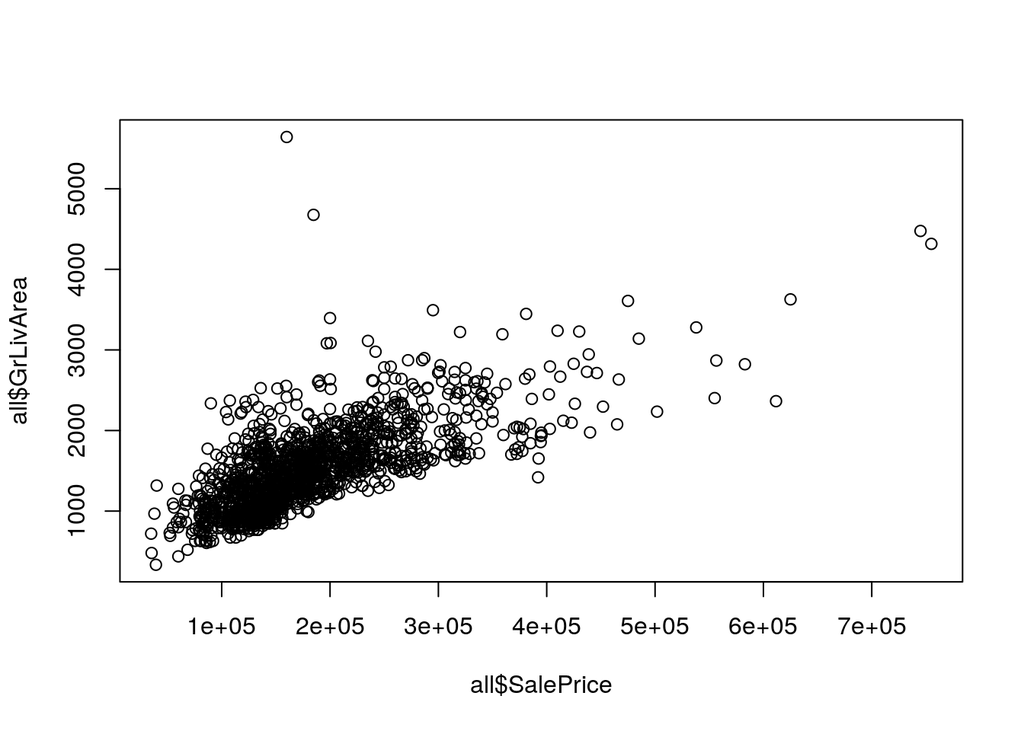

```r
plot(all$SalePrice, all$GrLivArea)
```

We can remove outliers from GrLivArea.

```r
train[which(train$GrLivArea > 4000), c("GrLivArea", "SalePrice")]
```

|  | GrLivArea | SalePrice |
| --- | --- | --- |
| 524 | 4676 | 12.12676 |
| 692 | 4316 | 13.53447 |
| 1183 | 4476 | 13.52114 |
| 1299 | 5642 | 11.98293 |

```r
train <- train[-c(524,1299),]
```

# Models

We will try different models but we are mainly interested in using random forests and gradient boosting. We use the Caret library to test some of the models.

```r
trnctrl <- trainControl(
  method = "repeatedcv",
  number = 2,
  repeats = 2
)

traind <- SalePrice ~ OverallQual + TotalSF + GrLivArea + ExterQual + KitchenQual + GarageCars + TotalBath + GarageArea + BsmtQual + TotalBsmtSF + X1stFlrSF + OverallGrade + FullBath + TotRmsAbvGrd + YearBuilt + YearRemodAdd  + ExterGrade + FireplaceQu + FireplaceScore + TotalSqFeet + TotalPorchSF + PoolScore + KitchenScore + Age + Remod + LotArea + YearBuilt + BsmtFinType1 + BsmtFinType2 + MSZoning

knn <- train(traind, data=train, method = "knn", trControl = trnctrl)
svm <- train(traind, data=train, method = "svmLinear", trControl = trnctrl)
#gbm <- train(traind, data=train, method = "gbm", trControl = trnctrl)
rf  <- train(traind, data=train, method = "rf", trControl = trnctrl)
```

We will now try xgboost and we will do hyperparameter search with Caret.

```r
#xgb_grid = expand.grid(
#  nrounds = 1000,
#  eta = c(0.1, 0.05, 0.01),
#  max_depth = c(2, 3, 4, 5, 6),
#  gamma = 0,
#  colsample_bytree = 1,
#  min_child_weight = c(1, 2, 3, 4 ,5),
#  subsample = 1
#)

xgb_grid = expand.grid(
  nrounds = 450,
  eta = 0.05,
  max_depth = 3,
  gamma = 0,
  colsample_bytree = 1,
  min_child_weight = 4,
  subsample = 1
)

xgb <- train(traind, data=train, method = "xgbTree", trControl = trnctrl, tuneGrid = xgb_grid)
```

```r
models = list(rf=rf, svm=svm, xgb=xgb, knn=knn)
results <- resamples(models)
summary(results)
```

```
##
## Call:
## summary.resamples(object = results)
##
## Models: rf, svm, xgb, knn
## Number of resamples: 4
##
## MAE
##           Min.    1st Qu.     Median       Mean    3rd Qu.       Max. NA's
## rf  0.09484232 0.09590017 0.09676344 0.09673287 0.09759614 0.09856228    0
## svm 0.08771771 0.08931307 0.09142725 0.09094203 0.09305622 0.09319593    0
## xgb 0.08868200 0.08929597 0.08990399 0.09033888 0.09094690 0.09286553    0
## knn 0.15746181 0.16129913 0.16295659 0.16201936 0.16367682 0.16470247    0
##
## RMSE
##          Min.   1st Qu.    Median      Mean   3rd Qu.      Max. NA's
## rf  0.1335479 0.1372215 0.1402523 0.1401268 0.1431576 0.1464549    0
## svm 0.1207836 0.1227679 0.1276771 0.1273993 0.1323085 0.1334594    0
## xgb 0.1257747 0.1268030 0.1284852 0.1298144 0.1314966 0.1365124    0
## knn 0.2245448 0.2249277 0.2256626 0.2256609 0.2263958 0.2267737    0
##
## Rsquared
##          Min.   1st Qu.    Median      Mean   3rd Qu.      Max. NA's
## rf  0.8727451 0.8740390 0.8787227 0.8792916 0.8839752 0.8869757    0
## svm 0.8899539 0.8932132 0.8985088 0.8987269 0.9040225 0.9079360    0
## xgb 0.8883223 0.8916080 0.8947127 0.8946036 0.8977083 0.9006668    0
## knn 0.6763123 0.6787673 0.6820450 0.6848424 0.6881201 0.6989672    0
```

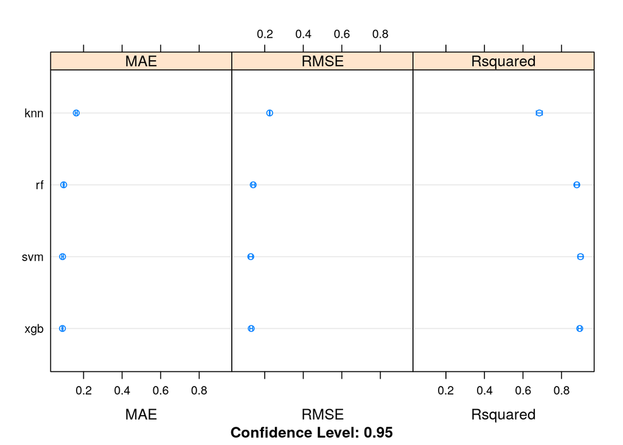

```r
dotplot(results)
```

# Prediction

We will now predict using test data with the xgb model. We will also call the exp function since we used log to normalize and now we must revert it.

```r
pred <- exp(predict(xgb, test))
summary(pred)
```

```
##    Min. 1st Qu.  Median    Mean 3rd Qu.    Max.
##   48985  128432  156672  179118  207846  764344
```

# Export

Finally, we create a CSV file so we can upload the results to Kaggle and we make sure that they have the correct column names.

```r
out <- data.frame(test$Id, pred)
colnames(out)[1]<-"Id"
colnames(out)[2]<-"SalePrice"
write.csv(out, file = "out.csv", row.names = F, quote=FALSE)
```

# Conclusion

With this approach we could get an RMSE of 0.13410. Further improvements can be made to achieve a better result.

# References

[1] https://rstudio-pubs-static.s3.amazonaws.com/349700_be0afbbec67a4b48a56878f32c28f710.html

[2] https://www.kaggle.com/erikbruin/house-prices-lasso-xgboost-and-a-detailed-eda  
[3] https://topepo.github.io/caret/available-models.html

[4] https://www.kaggle.com/c/house-prices-advanced-regression-techniques/kernels